# ggplot2 basics

John D. Lee

2/2/2020

This code provides a high level overview of ggplot, with examples of:

- mapping and setting aesthetic properties
- local and global mapping of aesthetic properties and overlaying summary data
- building a plot by adding layers including, sina plot, statistical models and faceting
- ordering facets to make differences clearer

## skimr, head, and tail to review the data

```r
sleep.df = sleepstudy # Read data from package

skim(sleep.df) # Summarizes dataframe
```

```
Skim summary statistics
 n obs: 180
 n variables: 3

── Variable type:factor ──────────────────────────────────────────────────────────────
 variable missing complete   n n_unique                         top_counts ordered
  Subject       0      180 180       18 308: 10, 309: 10, 310: 10, 330: 10   FALSE

── Variable type:numeric ─────────────────────────────────────────────────────────────
 variable missing complete   n   mean    sd     p0    p25    p50    p75   p100
     Days       0      180 180   4.5   2.88   0      2      4.5    7      9
 Reaction       0      180 180 298.51 56.33 194.33 255.38 288.65 336.75 466.35
     hist
 ▇▃▃▃▃▃▃▇
 ▂▇▇▆▆▃▁▁
```

```r
head(sleep.df) # First rows of dataframe
```

|  | Reaction | Days | Subject |
| --- | --- | --- | --- |
| 1 | 249.5600 | 0 | 308 |
| 2 | 258.7047 | 1 | 308 |
| 3 | 250.8006 | 2 | 308 |
| 4 | 321.4398 | 3 | 308 |
| 5 | 356.8519 | 4 | 308 |
| 6 | 414.6901 | 5 | 308 |

```r
tail(sleep.df) # Last rows of dataframe
```

|  | Reaction | Days | Subject |
| --- | --- | --- | --- |
| 175 | 287.1726 | 4 | 372 |
| 176 | 329.6076 | 5 | 372 |
| 177 | 334.4818 | 6 | 372 |
| 178 | 343.2199 | 7 | 372 |
| 179 | 369.1417 | 8 | 372 |
| 180 | 364.1236 | 9 | 372 |

```r
NA
```

## Simple scatterplot: Map variables to aesthetic properties of geometric elements

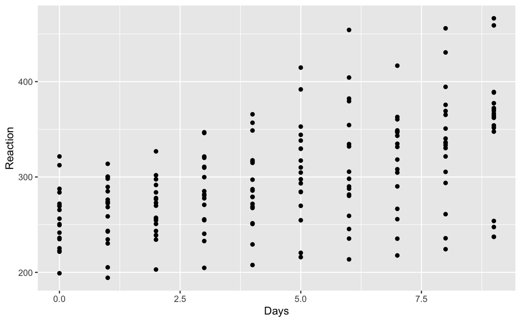

```r
ggplot(data = sleep.df, mapping = aes(x = Days, y = Reaction)) +
  geom_point()
```

## Simple scatterplot: Setting aesthetic properties

A common error is to map rather than set a color to a geom. These graphs show what happens.

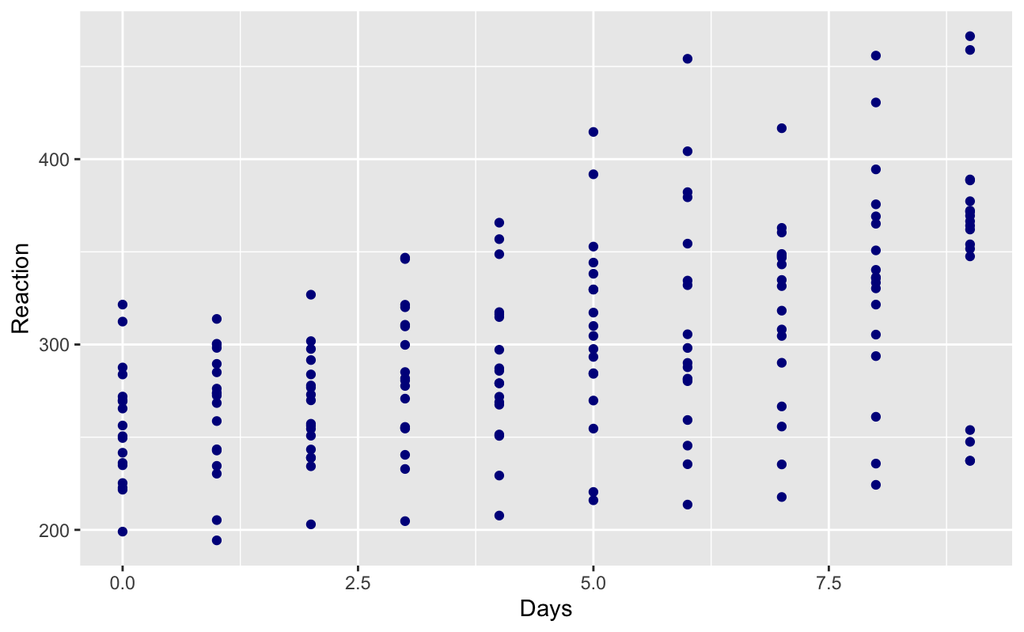

```r
ggplot(data = sleep.df, mapping = aes(x = Days, y = Reaction)) +
  geom_point(colour = "darkblue")
```

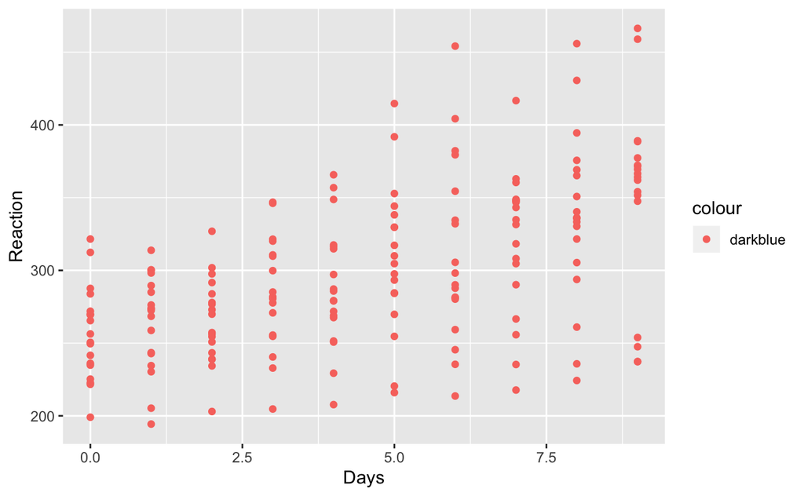

```r
ggplot(data = sleep.df, mapping = aes(x = Days, y = Reaction, colour = "darkblue")) +
  geom_point()
```

## Simple scatterplot: Layering geometric elements

Note that each layer is plotted on top of the previous layers. Here the violin plot lies beneath the sina plot.

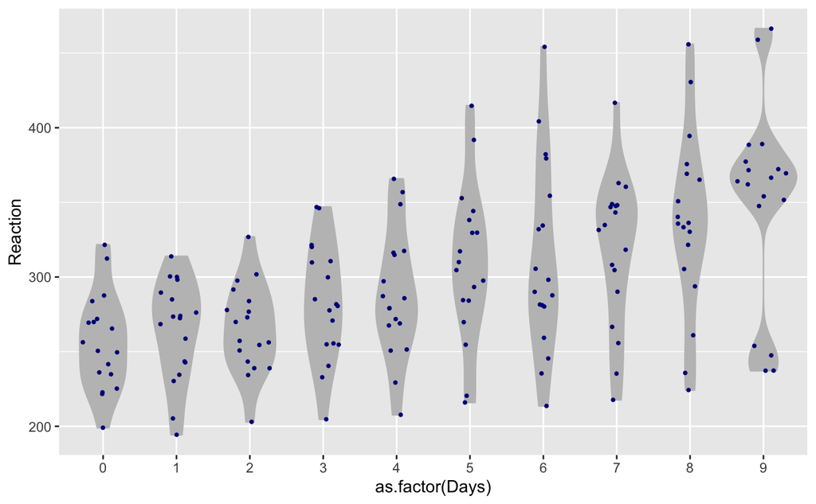

```r
ggplot(data = sleep.df, mapping = aes(x = as.factor(Days), y = Reaction)) +
  geom_violin(fill= "grey75", colour = "grey75") +
  geom_sina(colour = "darkblue", size = .7)
```

## Simple scatterplot: Local and global mapping

Use global mapping to minimize typing, ease revisions, and minimize confusing ambiguity.

Local mapping also makes it possible to add points from another data set.

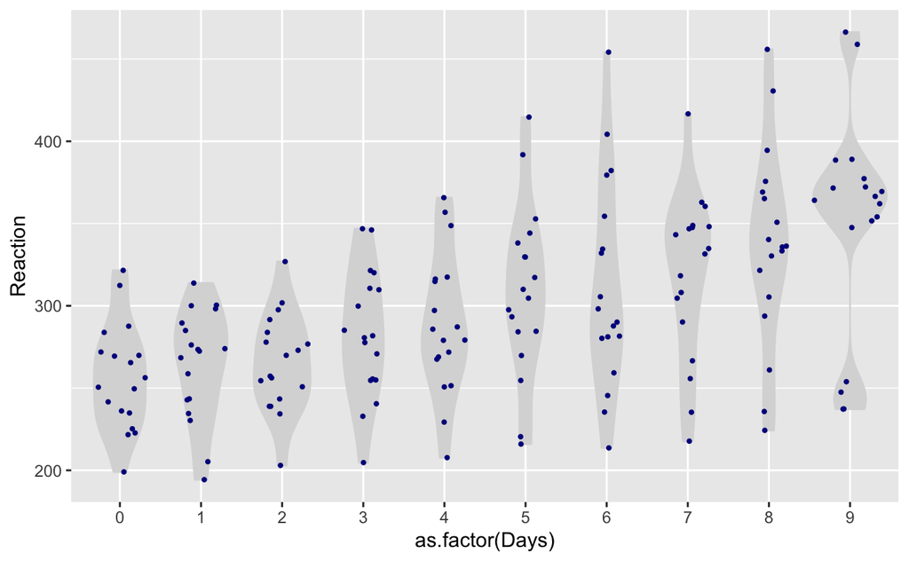

```r
## Global
ggplot(data = sleep.df, mapping = aes(x = as.factor(Days), y = Reaction)) +
  geom_violin(fill= "grey85", colour = "grey85") +
  geom_sina(colour = "darkblue", size = .7)
```

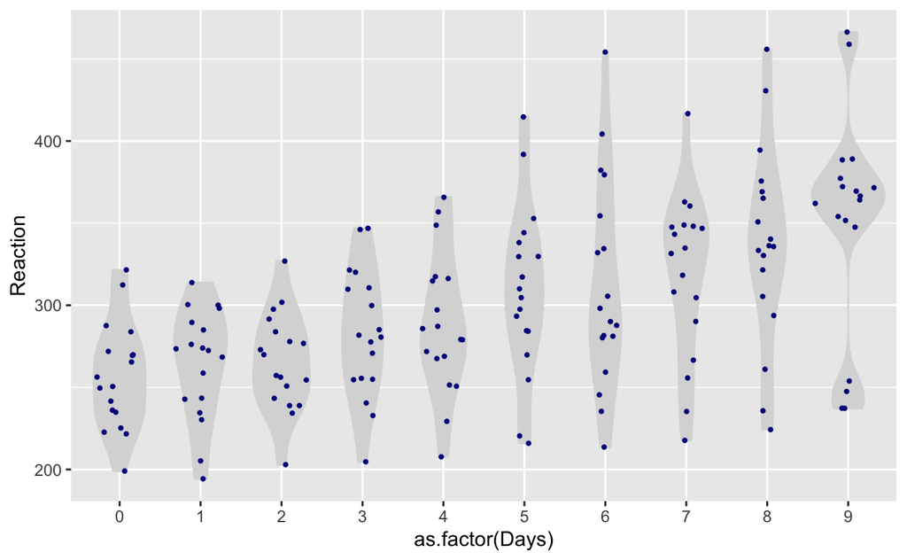

```r
## Local
ggplot(data = sleep.df) +
  geom_violin(mapping = aes(x = as.factor(Days), y = Reaction), fill= "grey85", colour = "grey85") +
  geom_sina(mapping = aes(x = as.factor(Days), y = Reaction), colour = "darkblue", size = .7)
```

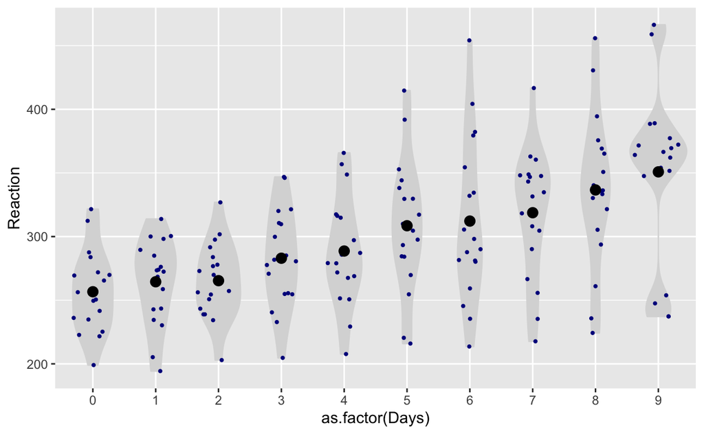

```r
## Local mapping to overlay data
m.sleep.df = sleep.df %>%
  group_by(Days) %>%
  summarise(m.reaction = mean(Reaction))

ggplot(data = sleep.df, mapping = aes(x = as.factor(Days), y = Reaction)) +
  geom_violin(fill= "grey85", colour = "grey85") +
  geom_sina(colour = "darkblue", size = .7) +
  geom_point(data = m.sleep.df, aes(y = m.reaction), size = 3)
```

A common error is failing to identify the groups that define the lines.

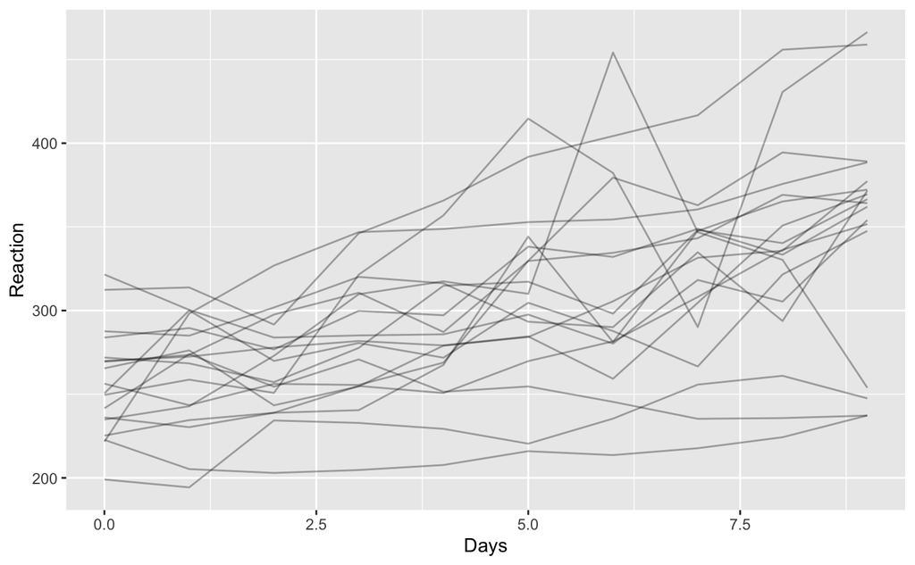

## Faceted scatterplot: Small multiples to show individual responses

facet_grid adds a different sort of layer that creates a graph for each combination of data defined by the grid variables, in this case “Subject”

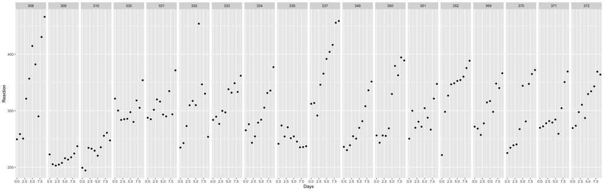

```r
ggplot(data = sleep.df, mapping = aes(x = Days, y = Reaction)) +
  geom_point() +
  facet_grid(.~Subject)
```

## Faceted Scatterplot with Loess Fit: A layer of loess fits shows a linear model doesn’t fit all participants

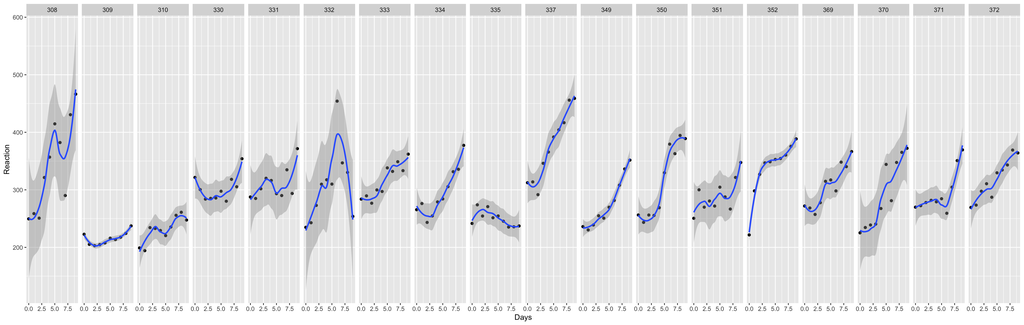

```r
ggplot(sleep.df, aes(Days, Reaction)) +
  geom_point() +
  geom_smooth(method = "loess") +
  facet_grid(.~Subject)
```

## Faceted scatterplot with linear regression: A linear model shows slopes and intercepts differ

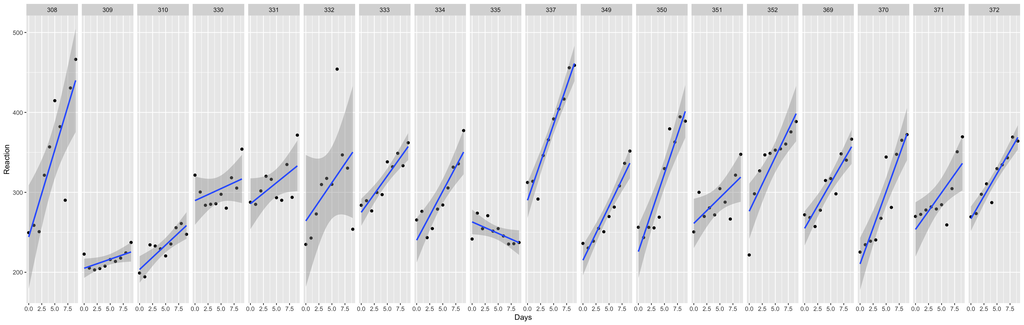

```r
ggplot(sleep.df, aes(Days, Reaction)) +
  geom_point() +
  geom_smooth(method = "lm") +
  facet_grid(.~Subject)
```

## Faceted scatterplot with linear regression: Subjects ordered by mean reaction time

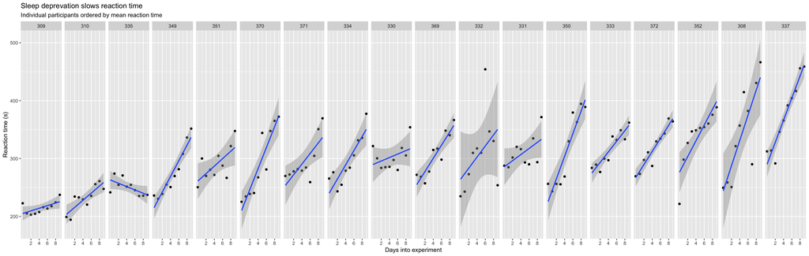

```r
ggplot(sleep.df, aes(Days, Reaction)) +
  geom_point() +
  geom_smooth(method = "lm") +
  facet_grid(.~reorder(x = Subject, X = Reaction, FUN = mean)) +
  scale_x_continuous(breaks = c(2, 4, 6, 8)) +
  labs(title = "Sleep deprevation slows reaction time",
       subtitle = "Individual participants ordered by mean reaction time",
       y = "Reaction time (s)", x = "Days into experiment")
```